# CSCI E-63C Week 10 Problem Set

# Sub-problem 2 (15 points): effect of signal magnitude

For training datasets with `nObs=100` and `500` observations simulate data as shown above with average differences between the two classes that are same as above, half of that and twice that (i.e. `deltaClass=0.5`, `1` and `2`). Obtain and plot test error rates of random forest, LDA and KNN for each of the six (two samples sizes times three signal magnitudes) combinations of sample size and signal strengths. As before use large test dataset (e.g. 10K observations or so) for greater stability of the results. Describe the most pronounced differences across error rates for those datasets: does the increase in the number of observations impact the error rate of the models? Does change in the magnitude of signal impact their performance? Are different classifier approaches impacted in a similar way?

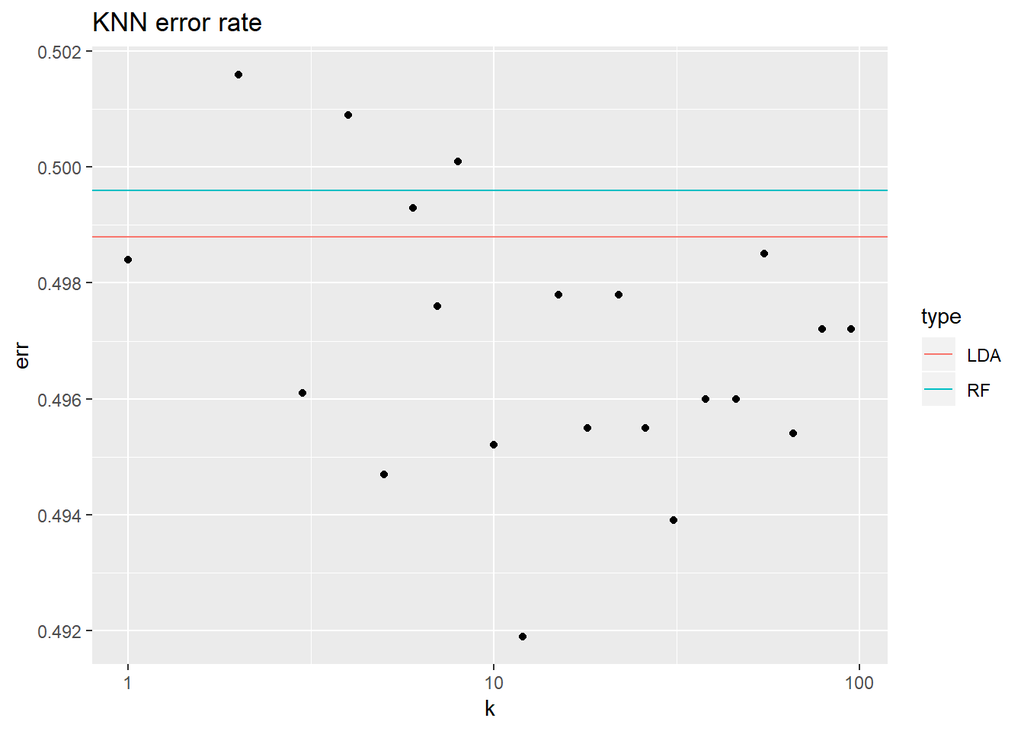

```r
set.seed(3)

# deltaClass = 0.5

# train data for 100 obs
data.100 = trainDataGen(nObs[2], nClassVars, nNoiseVars, deltaClass=0.5, classTrain=1, xyzTrain.100) # classTrain at index 2
classTrain.100 = unlist(data.100[1])
classTrain.100 = factor(classTrain.100 > 0)
#table(classTrain.100)

# train data for 500 obs
data.500 = trainDataGen(nObs[3], nClassVars, nNoiseVars, deltaClass=0.5, classTrain=1, xyzTrain.500)
classTrain.500 = unlist(data.500[1])
classTrain.500 = factor(classTrain.500 > 0)
#table(classTrain.500)

# RF
rf.100 = randomForestGen(xyzTrain.100, xyzTest.10K, classTrain.100, classTest.10K)
#rf.100
rf.500 = randomForestGen(xyzTrain.500, xyzTest.10K, classTrain.500, classTest.10K)
#rf.500

# lda
lda.100 = ldaGen(xyzTrain.100, xyzTest.10K, classTrain.100, classTest.10K)
#lda.100
lda.500 = ldaGen(xyzTrain.500, xyzTest.10K, classTrain.500, classTest.10K)
#lda.500

# knn
knn.100 = knnGen(100, xyzTrain.100, xyzTest.10K, classTrain.100, classTest.10K, lda.100, rf.100)
knn.100
```

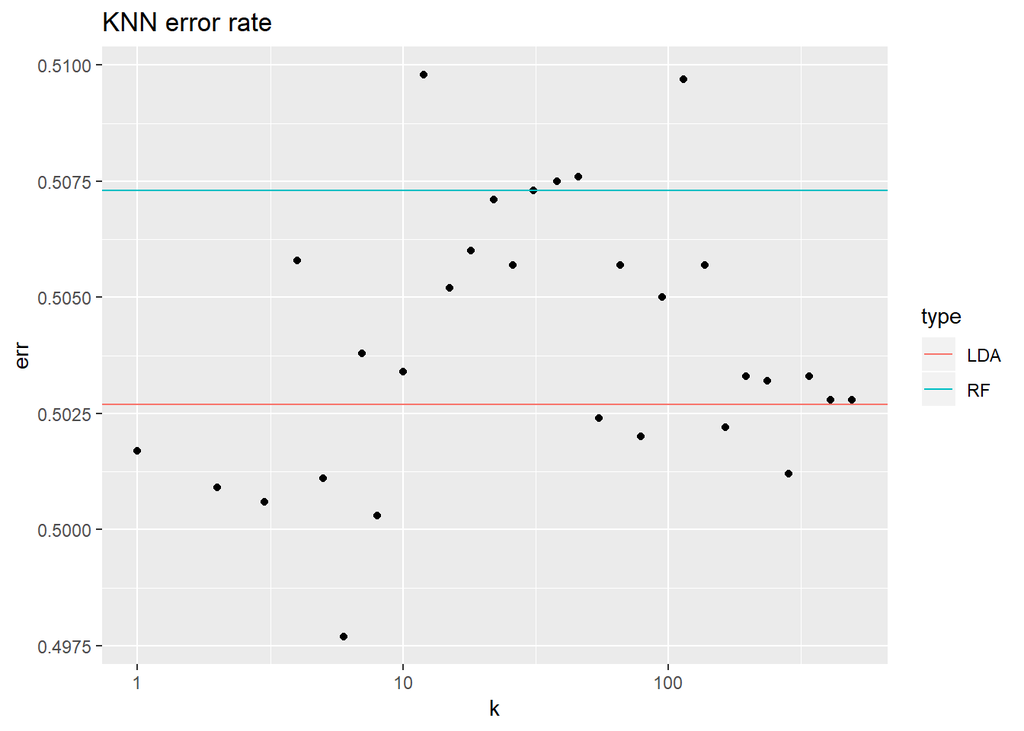

```r
knn.500 = knnGen(500, xyzTrain.500, xyzTest.10K, classTrain.500, classTest.10K, lda.500, rf.500)
knn.500
```

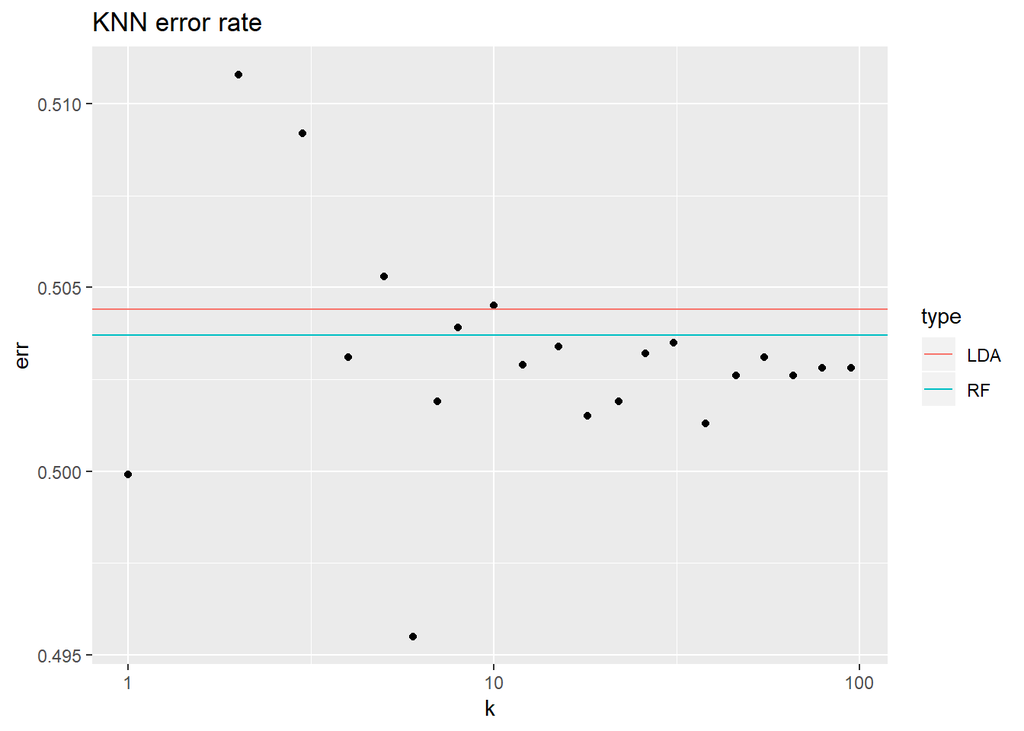

```r
# deltaClass = 1

# train data for 100 obs
data.100 = trainDataGen(nObs[2], nClassVars, nNoiseVars, deltaClass=1, classTrain=1, xyzTrain.100) # classTrain at index 2
classTrain.100 = unlist(data.100[1])
classTrain.100 = factor(classTrain.100 > 0)
#table(classTrain.100)

# train data for 500 obs
data.500 = trainDataGen(nObs[3], nClassVars, nNoiseVars, deltaClass=1, classTrain=1, xyzTrain.500)
classTrain.500 = unlist(data.500[1])
classTrain.500 = factor(classTrain.500 > 0)
#table(classTrain.500)

# RF
rf.100 = randomForestGen(xyzTrain.100, xyzTest.10K, classTrain.100, classTest.10K)
#rf.100
rf.500 = randomForestGen(xyzTrain.500, xyzTest.10K, classTrain.500, classTest.10K)
#rf.500

# lda
lda.100 = ldaGen(xyzTrain.100, xyzTest.10K, classTrain.100, classTest.10K)
#lda.100
lda.500 = ldaGen(xyzTrain.500, xyzTest.10K, classTrain.500, classTest.10K)
#lda.500

# knn
knn.100 = knnGen(100, xyzTrain.100, xyzTest.10K, classTrain.100, classTest.10K, lda.100, rf.100)
knn.100
```